# Curve Sketching

Yuanting Lu

10/14/2020

## The Meaning of $f'$

- $f(x)$ is increasing on the intervals where $f'(x)>0$.
- $f(x)$ is decreasing on the intervals where $f'(x)<0$.

**Example 1.** Find the intervals of increase and decrease for $f(x)=x^4-4x^3$.

Because $f'(x)=4x^3-12x^2=4x^2(x-3)$, we know the critical numbers are $x=0$ and $x=3$. So, the sign chart for $f'(x)$ is

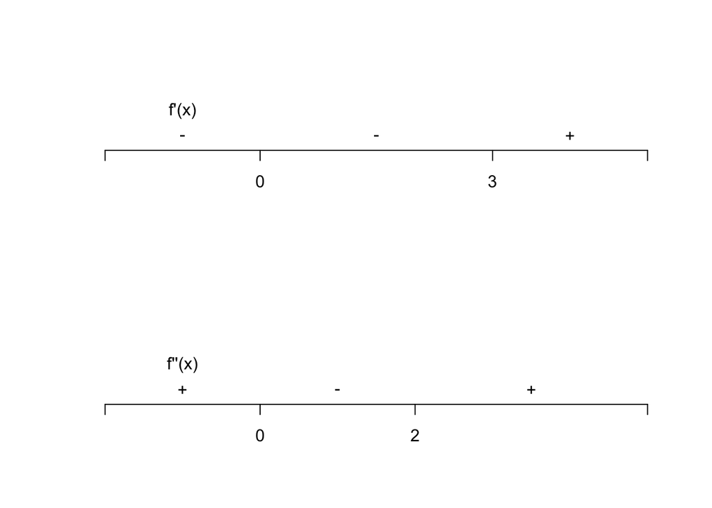

## The Meaning of $f''$

- $f(x)$ concaves up on the intervals where $f''(x)>0$.
- $f(x)$ concaves down on the intervals where $f''(x)<0$.

**Example 2.** Find the intervals of concavity for $f(x)=x^4-4x^3$.

Because $f''(x)=12x^2-24x=12x(x-2)$, we know the inflection points are at $x=0$ and $x=2$. So, the sign chart for $f''(x)$ is shown in the figure above.

## Practice Problems

For all the practice problems,

- Create a sign chart for $f'$ to find the intervals of increase and decrease.
- Create a sign chart for $f''$ to find the the inflection points and intervals of concavity.
- Identify the $y$-values of all the critical points and inflection points. Pin down them on the graph.
- Sketch the graph based on the information you learned from $f'$ and $f''$.
1. $f(x)=\frac{x^4}{2}-4x^2+3$.
2. $f(x)=5x^3-3x^5$.
3. $f(x)=\ln (x^2+9)$.
4. $f(x)=\dfrac{e^x}{1+e^x}$
5. $f(x)=\dfrac{e^x}{1-e^x}$